# Enviromental Analysis

Óscar Romero Báez

2022-05-23

### 1) Required libraries

```r
library(ggplot2)
library(nortest)
library(dplyr)
```

### 2) Required database is loaded

```r
#Enviromental variables databases
Sg.env<-read.table("Data/Env_Data/Env_Data.txt",header=T)

#Transform to factor some variables
Sg.env$ID<-factor(Sg.env$ID)
Sg.env$Site<-factor(Sg.env$Site)
Sg.env$Polygon<-factor(Sg.env$Polygon)
Sg.env$Site_ID<-factor(Sg.env$Site_ID)

#Explore data
str(Sg.env)
```

```
## 'data.frame':    109 obs. of  14 variables:
##  $ ID     : Factor w/ 109 levels "P5-O1","P5-O10",..: 16 26 27 28 29 30 17 18 19 20 ...
##  $ Site   : Factor w/ 2 levels "Agr","For": 2 2 2 2 2 2 2 2 2 2 ...
##  $ Polygon: Factor w/ 2 levels "P5","P6": 1 1 1 1 1 1 1 1 1 1 ...
##  $ Site_ID: Factor w/ 4 levels "P5Agr","P5For",..: 2 2 2 2 2 2 2 2 2 2 ...
##  $ St     : num  24.2 17.7 26.6 26.3 26.3 26.3 27 27 27 27 ...
##  $ At     : num  16.8 18.3 22.9 23.6 23.6 23.6 19 19 19 19 ...
##  $ RH     : num  42.5 42.5 42.5 42.5 42.5 ...
##  $ Slope  : num  4.52 0 13.9 22.48 22.48 ...
##  $ DEM    : int  2837 2838 2838 2832 2832 2832 2773 2773 2773 2773 ...
##  $ Aspect : num  198 0 225 245 245 ...
##  $ Soil   : int  1 1 1 1 1 1 1 1 1 1 ...
##  $ MSI    : num  0.74 0.736 0.775 0.781 0.781 ...
##  $ NDVI   : num  0.367 0.28 0.434 0.548 0.548 ...
##  $ Bt     : num  24.2 26.2 32.5 31.2 23.9 30.6 32.2 29.2 32.5 31.2 ...
```

```r
summary(Sg.env)
```

```
##        ID       Site    Polygon  Site_ID         St              At
##  P5-O1  :  1   Agr:49   P5:30   P5Agr:15   Min.   :14.10   Min.   :12.80
##  P5-O10 :  1   For:60   P6:79   P5For:15   1st Qu.:20.30   1st Qu.:17.50
##  P5-O11 :  1                    P6Agr:34   Median :21.80   Median :19.00
##  P5-O12 :  1                    P6For:45   Mean   :23.02   Mean   :19.88
##  P5-O13 :  1                               3rd Qu.:25.30   3rd Qu.:21.90
##  P5-O14 :  1                               Max.   :39.50   Max.   :30.80
##  (Other):103
##        RH            Slope             DEM           Aspect
##  Min.   :23.60   Min.   : 0.000   Min.   :2773   Min.   :  0.00
##  1st Qu.:36.80   1st Qu.: 2.264   1st Qu.:2876   1st Qu.: 14.04
##  Median :44.30   Median : 3.200   Median :2882   Median : 71.56
##  Mean   :43.45   Mean   : 6.309   Mean   :3077   Mean   :107.35
##  3rd Qu.:50.02   3rd Qu.: 9.876   3rd Qu.:3347   3rd Qu.:153.43
##  Max.   :68.60   Max.   :32.640   Max.   :3659   Max.   :354.81
##
##       Soil            MSI              NDVI              Bt
##  Min.   :1.000   Min.   :0.5403   Min.   :0.1651   Min.   :21.60
##  1st Qu.:1.000   1st Qu.:0.7576   1st Qu.:0.3814   1st Qu.:29.50
##  Median :1.000   Median :0.8451   Median :0.4621   Median :30.80
##  Mean   :1.523   Mean   :0.9085   Mean   :0.4829   Mean   :30.62
##  3rd Qu.:2.000   3rd Qu.:1.0210   3rd Qu.:0.6204   3rd Qu.:32.30
##  Max.   :4.000   Max.   :1.6008   Max.   :0.8603   Max.   :39.60
##
```

```r
#Polygon bases
P6<-read.table("Data/Env_Data/P6.txt",header=T)
P5<-read.table("Data/Env_Data/P5.txt",header=T)

#Sites base by polygon
P6For<-read.table("Data/Env_Data/P6For.txt",header=T)
P6Agr<-read.table("Data/Env_Data/P6Agr.txt",header=T)
P5For<-read.table("Data/Env_Data/P5For.txt",header=T)
P5Agr<-read.table("Data/Env_Data/P5Agr.txt",header=T)

#Landscape cover database
Sg.cov<-as.data.frame(read.table("Data/Env_Data/Cov_Data.txt",header=T))

#Transform to factor some variables
Sg.cov$Sites<-factor(Sg.cov$Sites)
Sg.cov$Coverage<-factor(Sg.cov$Coverage,labels=c("Agriculture","Bare soil","Forest","Roads"))

#Explore data
str(Sg.cov)
```

```
## 'data.frame':    16 obs. of  4 variables:
##  $ Polygon : chr  "P5" "P5" "P5" "P5" ...
##  $ Sites   : Factor w/ 4 levels "P5Agr","P5For",..: 2 2 2 2 1 1 1 1 4 4 ...
##  $ Coverage: Factor w/ 4 levels "Agriculture",..: 3 2 4 1 3 2 4 1 3 2 ...
##  $ Prop_Cov: num  0.973 0.025 0.003 0 0.603 0.064 0.035 0.298 0.941 0.047 ...
```

```r
summary(Sg.env)
```

```
##        ID       Site    Polygon  Site_ID         St              At
##  P5-O1  :  1   Agr:49   P5:30   P5Agr:15   Min.   :14.10   Min.   :12.80
##  P5-O10 :  1   For:60   P6:79   P5For:15   1st Qu.:20.30   1st Qu.:17.50
##  P5-O11 :  1                    P6Agr:34   Median :21.80   Median :19.00
##  P5-O12 :  1                    P6For:45   Mean   :23.02   Mean   :19.88
##  P5-O13 :  1                               3rd Qu.:25.30   3rd Qu.:21.90
##  P5-O14 :  1                               Max.   :39.50   Max.   :30.80
##  (Other):103
##        RH            Slope             DEM           Aspect
##  Min.   :23.60   Min.   : 0.000   Min.   :2773   Min.   :  0.00
##  1st Qu.:36.80   1st Qu.: 2.264   1st Qu.:2876   1st Qu.: 14.04
##  Median :44.30   Median : 3.200   Median :2882   Median : 71.56
##  Mean   :43.45   Mean   : 6.309   Mean   :3077   Mean   :107.35
##  3rd Qu.:50.02   3rd Qu.: 9.876   3rd Qu.:3347   3rd Qu.:153.43
##  Max.   :68.60   Max.   :32.640   Max.   :3659   Max.   :354.81
##
##       Soil            MSI              NDVI              Bt
##  Min.   :1.000   Min.   :0.5403   Min.   :0.1651   Min.   :21.60
##  1st Qu.:1.000   1st Qu.:0.7576   1st Qu.:0.3814   1st Qu.:29.50
##  Median :1.000   Median :0.8451   Median :0.4621   Median :30.80
##  Mean   :1.523   Mean   :0.9085   Mean   :0.4829   Mean   :30.62
##  3rd Qu.:2.000   3rd Qu.:1.0210   3rd Qu.:0.6204   3rd Qu.:32.30
##  Max.   :4.000   Max.   :1.6008   Max.   :0.8603   Max.   :39.60
##
```

### 3) Proportion of land cover for each site within each polygon

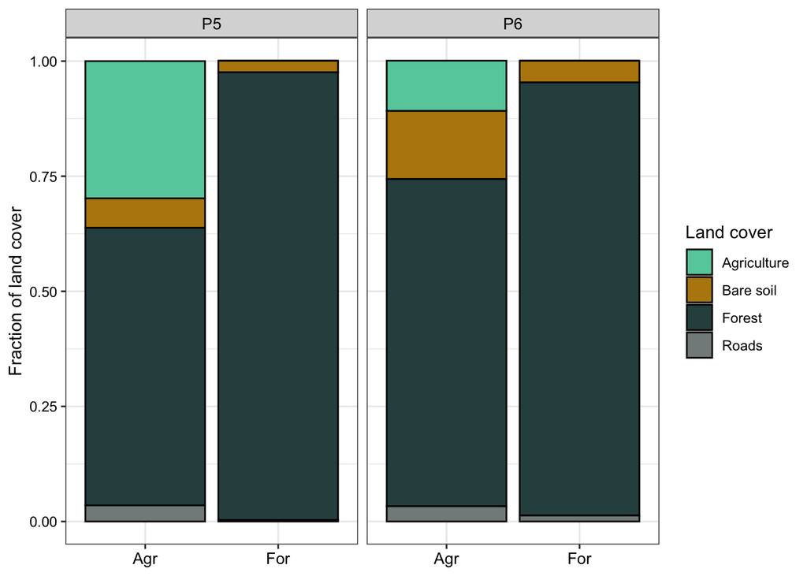

```r
(Sg.lancov<-ggplot(data=Sg.cov, #Database
            aes(x=Sites,y=Prop_Cov,fill=Coverage))+ #Axis definition
            geom_bar(stat="identity",color="black")+ #Geometry definition
            facet_wrap(~Polygon,scale="free_x")+ #Split plots
            ylab("Fraction of land cover")+ #y-axis legend
            scale_fill_manual(values=c("aquamarine3","darkgoldenrod","darkslategray","azure4"))+ #Colors definition
            theme_bw()+ #Canvas definition
            labs(fill="Land cover")+ #Rename legend
            scale_x_discrete(labels=c("Agr","For"))+ #Rename groups of x-axis
            theme(axis.title.x=element_blank(), #Remove title of x-axis
            strip.text.x=element_text(size=10,color="black"), #Size and color of strip.text.x
            axis.text.x=element_text(size=10,color="black"), #Size and color of axis.text.x
            axis.text.y=element_text(size=9,color="black"))) #Size and color of axis.text.y
```

Save plot to pdf file

```r
ggsave("Analysis/Env_Vars/Figures/Sg.lancov.pdf",dpi=300,limitsize=TRUE,
       width=10,height=7)
```

### 4) Necessary filters to carry out tests of normality and differentiation between sites within of the polygons

- Filters by sites within each polygon to realize test of normality for the variables

```r
#Extract samples of P6For site within Polygon 6
P6For<-filter(Sg.env,Site_ID == "P6For")

#Extract samples of P6Agr site within Polygon 6
P6Agr<-filter(Sg.env,Site_ID == "P6Agr")

#Extract samples of P5For site within Polygon 5
P5For<-filter(Sg.env,Site_ID == "P5For")

#Extract samples of P5Agr site within Polygon 5
P5Agr<-filter(Sg.env,Site_ID == "P5Agr")
```

- Filters by polygons to test differences between sites for variables

```r
#Extract samples from the P6For and P6Agr sites of Polygon 6 to perform differentiation tests
P6<-filter(Sg.env,Polygon == "P6")

#Extract samples from the P5For and P5Agr sites of Polygon 6 to perform differentiation tests
P5<-filter(Sg.env,Polygon == "P5")
```

5. Analysis of variables between sites within each polygon

#### Soil temperature (St)

1. Plot of St between sites within the polygons

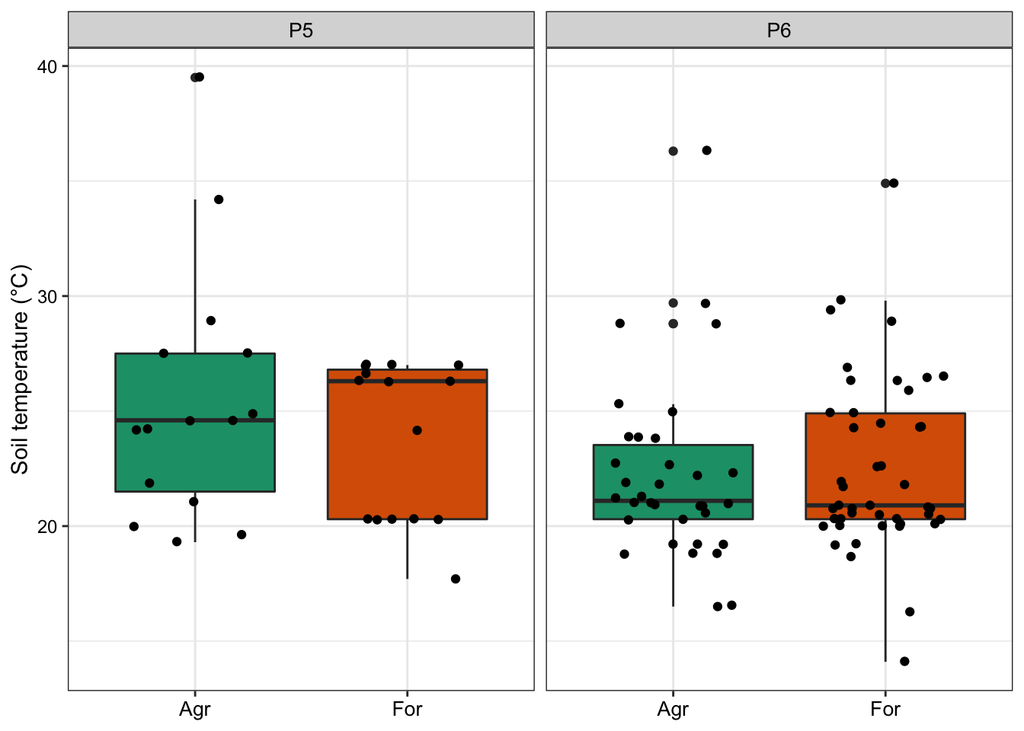

```r
#Plot with St between sites within polygons
(Sg.St.plot<-ggplot(data=Sg.env, #Database
             aes(x=Site_ID,y=St))+ #Axis definition
             geom_boxplot(aes(fill=Site))+ #Geometry definition
             geom_jitter(aes(fill=Site),width=0.3)+ #Geometry definition
             facet_wrap(~Polygon,scale="free_x")+ #Split plots
             ylab("Soil temperature (°C)")+ #y-axis legend
             scale_fill_brewer(palette="Dark2")+ #Colors definition
             scale_x_discrete(labels=c("Agr","For"))+ #Rename groups of x-axis
             theme_bw()+ #Canvas definition
             theme(legend.position="none",axis.title.x=element_blank(), #Remove title of x-axis
             strip.text.x=element_text(size=10,color="black"), #Size and color of strip.text.x
             axis.text.x=element_text(size=10,color="black"), #Size and color of axis.text.x
             axis.text.y=element_text(size=9,color="black"))) #Size and color of axis.text.y
```

Save plot to pdf file

```r
ggsave("Analysis/Env_Vars/Figures/Sg.St.plot.pdf",dpi=300,limitsize=TRUE,
       width=10,height=7)
```

2. Normality tests to determine if St has a normal distribution
- All sites

Normality test of St with all the data

```r
#Shapiro test used to n<50
#shapiro.test(Sg.env$St)

#Lillie test used to n>=50
lillie.test(Sg.env$St)
```

```
##
##  Lilliefors (Kolmogorov-Smirnov) normality test
##
## data:  Sg.env$St
## D = 0.14691, p-value = 4.64e-06
```

```r
#St for all data, non-normal
```

- By sites

Normality test for St within each site

P6For site

```r
shapiro.test(P6For$St) #(n<50)
```

```
##
##  Shapiro-Wilk normality test
##
## data:  P6For$St
## W = 0.91645, p-value = 0.003211
```

```r
#lillie.test(P6For$St) #(n>=50)
#St for P6For, non-normal
```

P6Agr site

```r
shapiro.test(P6Agr$St) #(n<50)
```

```
##
##  Shapiro-Wilk normality test
##
## data:  P6Agr$St
## W = 0.85519, p-value = 0.0003663
```

```r
#lillie.test(P6Agr$St) #(n>=50)
#St for P6Agr, non-normal
```

P5For site

```r
shapiro.test(P5For$St) #(n<50)
```

```
##
##  Shapiro-Wilk normality test
##
## data:  P5For$St
## W = 0.78307, p-value = 0.002248
```

```r
#lillie.test(P5For$St) #(n>=50)
#St for P5For, non-normal
```

P5Agr site

```r
#P5Agr
shapiro.test(P5Agr$St) #(n<50)
```

```
##
##  Shapiro-Wilk normality test
##
## data:  P5Agr$St
## W = 0.87846, p-value = 0.045
```

```r
#lillie.test(P5Agr$St) #(n>=50)
#St for P5Agr, non-normal
```

If the variable does not have a normal distribution, a non-parametric test (Wilcox test) was performed to find out if there were significant differences between the variables within the sites per polygon.

If both sites were found to have a normal distribution, a parametric test (Student’s t-test) was performed to see if there were any significant differences.

If a site is found to have a normal distribution, the Wilcox test and Student’s t-test were applied to compare the results of both tests.

3. Test to find if there are significant differences in St
- Between polygons

Search for significant differences between polygons

```r
wilcox.test(data=Sg.env,St~Polygon,exact=F)
```

```
##
##  Wilcoxon rank sum test with continuity correction
##
## data:  St by Polygon
## W = 1524.5, p-value = 0.02134
## alternative hypothesis: true location shift is not equal to 0
```

```r
#If there are significant differences between polygons
```

-Between sites within each polygon

Search for significant differences between sites within polygon 6

```r
wilcox.test(data=P6,St~Site,exact=F)
```

```
##
##  Wilcoxon rank sum test with continuity correction
##
## data:  St by Site
## W = 748.5, p-value = 0.874
## alternative hypothesis: true location shift is not equal to 0
```

```r
#No significant differences
```

Search for significant differences between sites within polygon 5

```r
wilcox.test(data=P5,St~Site,exact=F)
```

```
##
##  Wilcoxon rank sum test with continuity correction
##
## data:  St by Site
## W = 124, p-value = 0.6467
## alternative hypothesis: true location shift is not equal to 0
```

```r
#No significant differences
```

#### Air temperature (At)

1. Plot of At between sites within the polygons

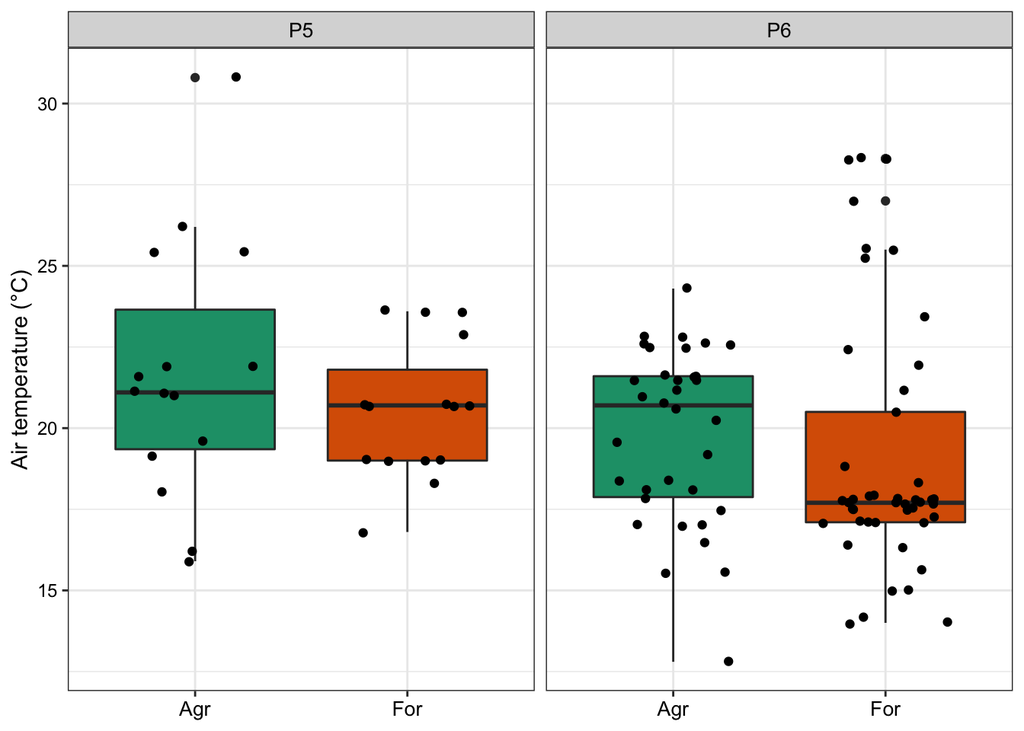

```r
#Plot with St between sites within polygons
(Sg.At.plot<-ggplot(data=Sg.env, #Database
             aes(x=Site_ID,y=At))+ #Axis definition
             geom_boxplot(aes(fill=Site))+ #Geometry definition
             geom_jitter(aes(fill=Site),width=0.3)+ #Geometry definition
             facet_wrap(~Polygon,scale="free_x")+ #Split plots
             ylab("Air temperature (°C)")+ #y-axis legend
             scale_fill_brewer(palette="Dark2")+ #Colors definition
             scale_x_discrete(labels=c("Agr","For"))+ #Rename groups of x-axis
             theme_bw()+ #Canvas definition
             theme(legend.position="none",axis.title.x=element_blank(), #Remove title of x-axis
             strip.text.x=element_text(size=10,color="black"), #Size and color of strip.text.x
             axis.text.x=element_text(size=10,color="black"), #Size and color of axis.text.x
             axis.text.y=element_text(size=9,color="black"))) #Size and color of axis.text.y
```

Save plot to pdf file

```r
ggsave("Analysis/Env_Vars/Figures/Sg.At.plot.pdf",dpi=300,limitsize=TRUE,
       width=10,height=7)
```

2. Normality tests to determine if At has a normal distribution
- All sites

Normality test of At with all the data

```r
#The activated test is the one used depending on the number of n of the sample
#Lillie test used to n>=50
lillie.test(Sg.env$At)
```

```
##
##  Lilliefors (Kolmogorov-Smirnov) normality test
##
## data:  Sg.env$At
## D = 0.12507, p-value = 0.0002454
```

```r
#At for all data, non-normal
```

- By sites

Normality test for At within each site

P6For site

```r
shapiro.test(P6For$At) #(n<50)
```

```
##
##  Shapiro-Wilk normality test
##
## data:  P6For$At
## W = 0.81648, p-value = 5.591e-06
```

```r
#lillie.test(P6For$At) #(n>=50)
#St for P6For, non-normal
```

P6Agr site

```r
shapiro.test(P6Agr$At) #(n<50)
```

```
##
##  Shapiro-Wilk normality test
##
## data:  P6Agr$At
## W = 0.9397, p-value = 0.06038
```

```r
#lillie.test(P6Agr$At) #(n>=50)
#At for P6Agr, normal
```

P5For site

```r
shapiro.test(P5For$At) #(n<50)
```

```
##
##  Shapiro-Wilk normality test
##
## data:  P5For$At
## W = 0.90653, p-value = 0.1198
```

```r
#lillie.test(P5For$At) #(n>=50)
#St for P5For, normal
```

P5Agr site

```r
#P5Agr
shapiro.test(P5Agr$At) #(n<50)
```

```
##
##  Shapiro-Wilk normality test
##
## data:  P5Agr$At
## W = 0.94319, p-value = 0.4242
```

```r
#lillie.test(P5Agr$At) #(n>=50)
#St for P5Agr, normal
```

Search for significant differences between polygons

```r
#Search for significant differences between sites within polygon 6
wilcox.test(data=Sg.env,At~Polygon,exact=F)
```

```
##
##  Wilcoxon rank sum test with continuity correction
##
## data:  At by Polygon
## W = 1569, p-value = 0.00924
## alternative hypothesis: true location shift is not equal to 0
```

```r
#If there are significant differences between polygons
```

-Between sites within each polygon

Search for significant differences between sites within polygon 6

```r
wilcox.test(data=P6,At~Site,exact=F)
```

```
##
##  Wilcoxon rank sum test with continuity correction
##
## data:  At by Site
## W = 953, p-value = 0.06314
## alternative hypothesis: true location shift is not equal to 0
```

```r
#No significant differences
```

```r
t.test(data=P6,At~Site,alternative="two.sided")
```

```
##
##  Welch Two Sample t-test
##
## data:  At by Site
## t = 0.99993, df = 76.409, p-value = 0.3205
## alternative hypothesis: true difference in means between group Agr and group For is not equal to 0
## 95 percent confidence interval:
##  -0.737249  2.224177
## sample estimates:
## mean in group Agr mean in group For
##          19.83235          19.08889
```

```r
#No significant differences
```

Search for significant differences between sites within polygon 5

```r
t.test(data=P5,At~Site,alternative="two.sided")
```

```
##
##  Welch Two Sample t-test
##
## data:  At by Site
## t = 0.97095, df = 21.324, p-value = 0.3425
## alternative hypothesis: true difference in means between group Agr and group For is not equal to 0
## 95 percent confidence interval:
##  -1.284243  3.537576
## sample estimates:
## mean in group Agr mean in group For
##          21.68000          20.55333
```

```r
#No significant differences
```

#### Relative Humidity (RH)

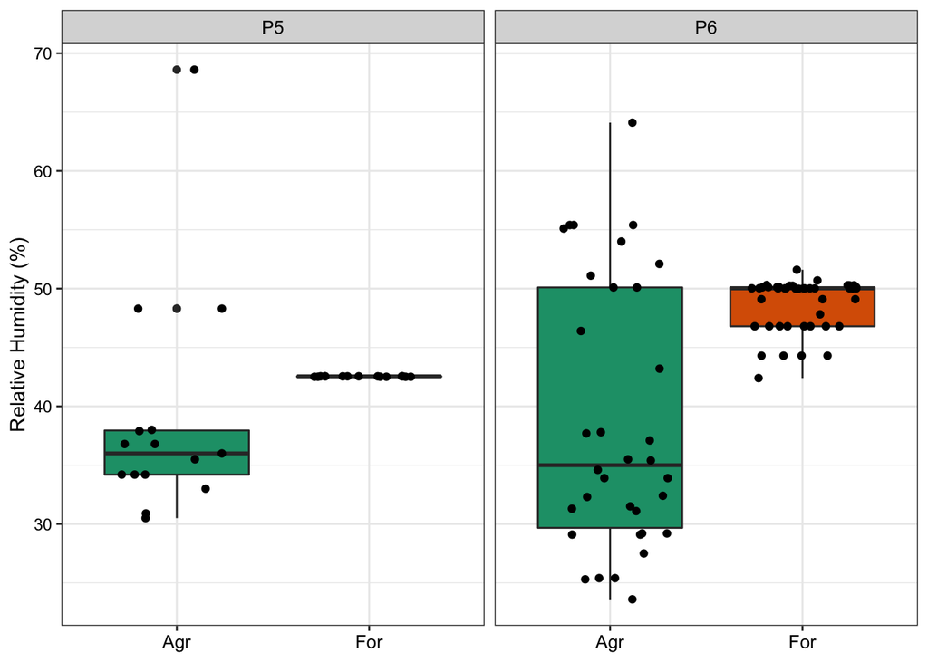

```r
#Plot with St between sites within polygons
(Sg.RH.plot<-ggplot(data=Sg.env, #Database
             aes(x=Site_ID,y=RH))+ #Axis definition
             geom_boxplot(aes(fill=Site))+ #Geometry definition
             geom_jitter(aes(fill=Site),width=0.3)+ #Geometry definition
             facet_wrap(~Polygon,scale="free_x")+ #Split plots
             ylab("Relative Humidity (%)")+ #y-axis legend
             scale_fill_brewer(palette="Dark2")+ #Colors definition
             scale_x_discrete(labels=c("Agr","For"))+ #Rename groups of x-axis
             theme_bw()+ #Canvas definition
             theme(legend.position="none",axis.title.x=element_blank(), #Remove title of x-axis
             strip.text.x=element_text(size=10,color="black"), #Size and color of strip.text.x
             axis.text.x=element_text(size=10,color="black"), #Size and color of axis.text.x
             axis.text.y=element_text(size=9,color="black"))) #Size and color of axis.text.y
```

Save plot to pdf file

```r
ggsave("Analysis/Env_Vars/Figures/Sg.RH.plot.pdf",dpi=300,limitsize=TRUE,
       width=10,height=7)
```

2. Normality tests to determine if RH has a normal distribution
- All sites

Normality test of RH with all the data

```r
#The activated test is the one used depending on the number of n of the sample

#Shapiro test used to n<50
#shapiro.test(Sg.env$RH)

#Lillie test used to n>=50
lillie.test(Sg.env$RH)
```

```
##
##  Lilliefors (Kolmogorov-Smirnov) normality test
##
## data:  Sg.env$RH
## D = 0.13989, p-value = 1.804e-05
```

```r
#At for all data, non-normal
```

- By sites

Normality test for RH within each site

P6For site

```r
shapiro.test(P6For$RH) #(n<50)
```

```
##
##  Shapiro-Wilk normality test
##
## data:  P6For$RH
## W = 0.7661, p-value = 4.622e-07
```

```r
#lillie.test(P6For$RH) #(n>=50)
#St for P6For, non-normal
```

P6Agr site

```r
shapiro.test(P6Agr$RH) #(n<50)
```

```
##
##  Shapiro-Wilk normality test
##
## data:  P6Agr$RH
## W = 0.90042, p-value = 0.004705
```

```r
#lillie.test(P6Agr$RH) #(n>=50)
#At for P6Agr, non-normal
```

P5For site

```r
shapiro.test(P5For$RH) #(n<50)
```

```
##
##  Shapiro-Wilk normality test
##
## data:  P5For$RH
## W = 0.6856, p-value = 0.0001751
```

```r
#lillie.test(P5For$RH) #(n>=50)
#St for P5For, non-normal
```

P5Agr site

```r
#P5Agr
shapiro.test(P5Agr$RH) #(n<50)
```

```
##
##  Shapiro-Wilk normality test
##
## data:  P5Agr$RH
## W = 0.71075, p-value = 0.0003246
```

```r
#lillie.test(P5Agr$RH) #(n>=50)
#St for P5Agr, non-normal
```

3. Test to find if there are significant differences in RH
- Between polygons

Search for significant differences between polygons

```r
#Search for significant differences between sites within polygon 6
wilcox.test(data=Sg.env,RH~Polygon,exact=F)
```

```
##
##  Wilcoxon rank sum test with continuity correction
##
## data:  RH by Polygon
## W = 699.5, p-value = 0.0009948
## alternative hypothesis: true location shift is not equal to 0
```

```r
#If there are significant differences between polygons
```

-Between sites within each polygon

Search for significant differences between sites within polygon 6

```r
wilcox.test(data=P6,RH~Site,exact=F)
```

```
##
##  Wilcoxon rank sum test with continuity correction
##
## data:  RH by Site
## W = 430, p-value = 0.0009158
## alternative hypothesis: true location shift is not equal to 0
```

```r
#If there are significant differences between polygons
```

Search for significant differences between sites within polygon 5

```r
wilcox.test(data=P5,RH~Site,exact=F)
```

```
##
##  Wilcoxon rank sum test with continuity correction
##
## data:  RH by Site
## W = 45, p-value = 0.005247
## alternative hypothesis: true location shift is not equal to 0
```

```r
#If there are significant differences between polygons
```

#### Slope

1. Plot of Slope between sites within the polygons

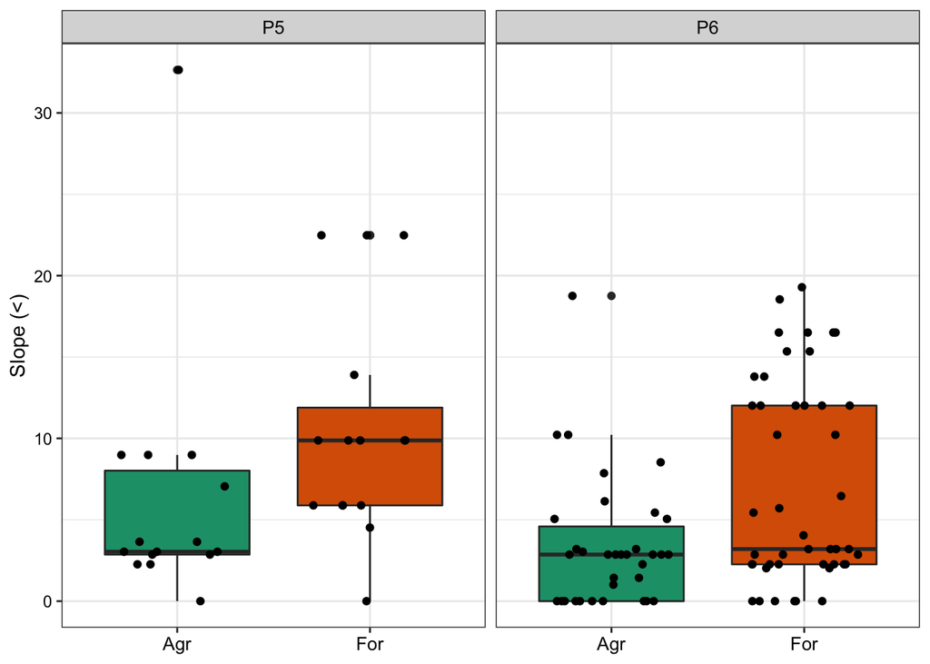

```r
#Plot with St between sites within polygons
(Sg.Slope.plot<-ggplot(data=Sg.env, #Database
             aes(x=Site_ID,y=Slope))+ #Axis definition
             geom_boxplot(aes(fill=Site))+ #Geometry definition
             geom_jitter(aes(fill=Site),width=0.3)+ #Geometry definition
             facet_wrap(~Polygon,scale="free_x")+ #Split plots
             ylab("Slope (<)")+ #y-axis legend
             scale_fill_brewer(palette="Dark2")+ #Colors definition
             scale_x_discrete(labels=c("Agr","For"))+ #Rename groups of x-axis
             theme_bw()+ #Canvas definition
             theme(legend.position="none",axis.title.x=element_blank(), #Remove title of x-axis
             strip.text.x=element_text(size=10,color="black"), #Size and color of strip.text.x
             axis.text.x=element_text(size=10,color="black"), #Size and color of axis.text.x
             axis.text.y=element_text(size=9,color="black"))) #Size and color of axis.text.y
```

Save plot to pdf file

```r
ggsave("Analysis/Env_Vars/Figures/Sg.Slope.plot.pdf",dpi=300,limitsize=TRUE,
       width=10,height=7)
```

Normality test of Slope with all the data

```r
#The activated test is the one used depending on the number of n of the sample

#Shapiro test used to n<50
#shapiro.test(Sg.env$Slope)

#Lillie test used to n>=50
lillie.test(Sg.env$Slope)
```

```
##
##  Lilliefors (Kolmogorov-Smirnov) normality test
##
## data:  Sg.env$Slope
## D = 0.21101, p-value = 5.42e-13
```

```r
#At for all data, non-normal
```

- By sites

P6For site

```r
shapiro.test(P6For$Slope) #(n<50)
```

```
##
##  Shapiro-Wilk normality test
##
## data:  P6For$Slope
## W = 0.85924, p-value = 6.385e-05
```

```r
#lillie.test(P6For$Slope) #(n>=50)
#St for P6For, non-normal
```

P6Agr site

```r
shapiro.test(P6Agr$Slope) #(n<50)
```

```
##
##  Shapiro-Wilk normality test
##
## data:  P6Agr$Slope
## W = 0.77563, p-value = 8.957e-06
```

```r
#lillie.test(P6Agr$Slope) #(n>=50)
#At for P6Agr, non-normal
```

P5For site

```r
shapiro.test(P5For$Slope) #(n<50)
```

```
##
##  Shapiro-Wilk normality test
##
## data:  P5For$Slope
## W = 0.85666, p-value = 0.0216
```

```r
#lillie.test(P5For$Slope) #(n>=50)
#St for P5For, non-normal
```

P5Agr site

```r
#P5Agr
shapiro.test(P5Agr$Slope) #(n<50)
```

```
##
##  Shapiro-Wilk normality test
##
## data:  P5Agr$Slope
## W = 0.59037, p-value = 2.08e-05
```

```r
#lillie.test(P5Agr$Slope) #(n>=50)
#St for P5Agr, non-normal
```

3. Test to find if there are significant differences in Slope
- Between polygons

Search for significant differences between polygons

```r
#Search for significant differences between sites within polygon 6
wilcox.test(data=Sg.env,Slope~Polygon,exact=F)
```

```
##
##  Wilcoxon rank sum test with continuity correction
##
## data:  Slope by Polygon
## W = 1531.5, p-value = 0.01852
## alternative hypothesis: true location shift is not equal to 0
```

```r
#If there are significant differences between polygons
```

-Between sites within each polygon

Search for significant differences between sites within polygon 6

```r
wilcox.test(data=P6,Slope~Site,exact=F)
```

```
##
##  Wilcoxon rank sum test with continuity correction
##
## data:  Slope by Site
## W = 511.5, p-value = 0.01169
## alternative hypothesis: true location shift is not equal to 0
```

```r
#If there are significant differences between polygons
```

Search for significant differences between sites within polygon 5

```r
wilcox.test(data=P5,Slope~Site,exact=F)
```

```
##
##  Wilcoxon rank sum test with continuity correction
##
## data:  Slope by Site
## W = 48.5, p-value = 0.00811
## alternative hypothesis: true location shift is not equal to 0
```

```r
#If there are significant differences between polygons
```

#### Digital elevation model (DEM)

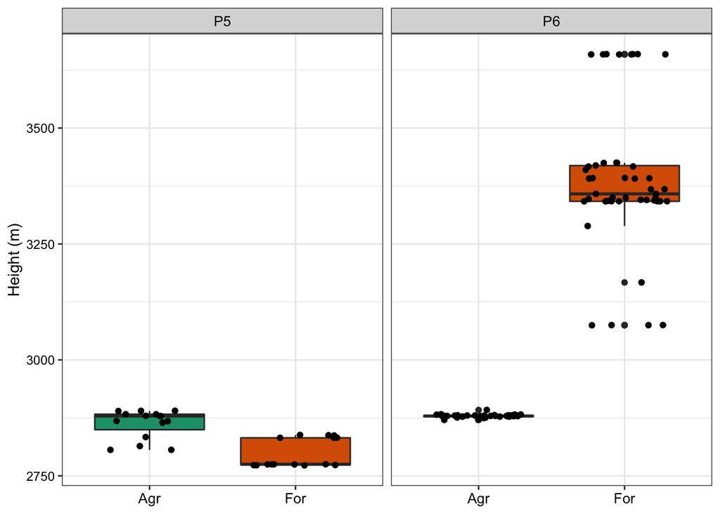

```r
#Plot with St between sites within polygons
(Sg.DEM.plot<-ggplot(data=Sg.env, #Database
             aes(x=Site_ID,y=DEM))+ #Axis definition
             geom_boxplot(aes(fill=Site))+ #Geometry definition
             geom_jitter(aes(fill=Site),width=0.3)+ #Geometry definition
             facet_wrap(~Polygon,scale="free_x")+ #Split plots
             ylab("Height (m)")+ #y-axis legend
             scale_fill_brewer(palette="Dark2")+ #Colors definition
             scale_x_discrete(labels=c("Agr","For"))+ #Rename groups of x-axis
             theme_bw()+ #Canvas definition
             theme(legend.position="none",axis.title.x=element_blank(), #Remove title of x-axis
             strip.text.x=element_text(size=10,color="black"), #Size and color of strip.text.x
             axis.text.x=element_text(size=10,color="black"), #Size and color of axis.text.x
             axis.text.y=element_text(size=9,color="black"))) #Size and color of axis.text.y
```

Save plot to pdf file

```r
ggsave("Analysis/Env_Vars/Figures/Sg.DEM.plot.pdf",dpi=300,limitsize=TRUE,
       width=10,height=7)
```

2. Normality tests to determine if DEM has a normal distribution
- All sites

Normality test of DEM with all the data

```r
#The activated test is the one used depending on the number of n of the sample

#Shapiro test used to n<50
#shapiro.test(Sg.env$DEM)

#Lillie test used to n>=50
lillie.test(Sg.env$DEM)
```

```
##
##  Lilliefors (Kolmogorov-Smirnov) normality test
##
## data:  Sg.env$DEM
## D = 0.32945, p-value < 2.2e-16
```

```r
#At for all data, non-normal
```

- By sites

Normality test for DEM within each site

P6For site

```r
shapiro.test(P6For$DEM) #(n<50)
```

```
##
##  Shapiro-Wilk normality test
##
## data:  P6For$DEM
## W = 0.83856, p-value = 1.884e-05
```

```r
#lillie.test(P6For$DEM) #(n>=50)
#St for P6For, non-normal
```

P6Agr site

```r
shapiro.test(P6Agr$DEM) #(n<50)
```

```
##
##  Shapiro-Wilk normality test
##
## data:  P6Agr$DEM
## W = 0.84212, p-value = 0.0001875
```

```r
#lillie.test(P6Agr$DEM) #(n>=50)
#At for P6Agr, non-normal
```

P5For site

```r
shapiro.test(P5For$DEM) #(n<50)
```

```
##
##  Shapiro-Wilk normality test
##
## data:  P5For$DEM
## W = 0.6734, p-value = 0.0001309
```

```r
#lillie.test(P5For$DEM) #(n>=50)
#St for P5For, non-normal
```

P5Agr site

```r
#P5Agr
shapiro.test(P5Agr$DEM) #(n<50)
```

```
##
##  Shapiro-Wilk normality test
##
## data:  P5Agr$DEM
## W = 0.7845, p-value = 0.002342
```

```r
#lillie.test(P5Agr$DEM) #(n>=50)
#St for P5Agr, non-normal
```

3. Test to find if there are significant differences in DEM
- Between polygons

Search for significant differences between polygons

```r
#Search for significant differences between sites within polygon 6
wilcox.test(data=Sg.env,DEM~Polygon,exact=F)
```

```
##
##  Wilcoxon rank sum test with continuity correction
##
## data:  DEM by Polygon
## W = 209, p-value = 3.401e-11
## alternative hypothesis: true location shift is not equal to 0
```

```r
#If there are significant differences between polygons
```

-Between sites within each polygon

Search for significant differences between sites within polygon 6

```r
wilcox.test(data=P6,DEM~Site,exact=F)
```

```
##
##  Wilcoxon rank sum test with continuity correction
##
## data:  DEM by Site
## W = 0, p-value = 3.256e-14
## alternative hypothesis: true location shift is not equal to 0
```

```r
#If there are significant differences between polygons
```

Search for significant differences between sites within polygon 5

```r
wilcox.test(data=P5,DEM~Site,exact=F)
```

```
##
##  Wilcoxon rank sum test with continuity correction
##
## data:  DEM by Site
## W = 204, p-value = 0.0001483
## alternative hypothesis: true location shift is not equal to 0
```

```r
#If there are significant differences between polygons
```